# Adrien HANS & Tanguy JEANNEAU

# EnsLearn - TP n°2

```python
import numpy as np
import matplotlib.pyplot as plt
import seaborn as sns
```

## Exercice 1 : Fusion de capteurs de variances connues

On suppose que les distributions sont normales :

$$X_1 \sim \mathcal{N}(x,\sigma_1)$$$$X_2 \sim \mathcal{N}(x,\sigma_2)$$

où $X_1$ et $X_2$ sont les deux variables aléatoires représentant les deux capteurs.

On note $n_1$ le cardinal de $D^{(1)}$ et $n_2$ celui de $D^{(2)}$

### Question 1 :

En prenant : $$x=4$$ $$\sigma_1=0.1$$ $$\sigma_2=0.3$$ $$n_1=4$$ $$n_2=10$$ on génère les propositions $D^{(1)}$ et $D^{(2)}$ :

```python
#Initialisation :
x=4 #solution recherchée
sigma1=0.1
sigma2=0.3
n1=4 #Cardinal de D1
n2=10 #Cardinal de D2

#fonction D(x,sigma,n) pour générer chaque propostion.
def D(x,sigma,n):
    D=np.random.normal(x,sigma,n)
    return D

D1=D(x,sigma1,n1)
D2=D(x, sigma2,n2)
print('D1 : ', D1)
print('D2 : ', D2)
```

```
D1 :  [4.03453666 3.90978356 4.20540167 4.12578416]
D2 :  [4.31061959 4.17063513 4.02107696 4.60301784 3.53715415 4.05954314
 4.20654942 3.86213535 3.42780753 4.01981326]
```

### Question 2 :

*Pour 1000 réalisations, calculez l’agrégat $\overline{x}$ obtenu par maximum de vraisemblance et par simple moyenne arithmétique. Tracez les histogrammes (entre -0.3 et 0.3 pour 50 bins) relatifs aux deux méthodes. Discutez le résultat.*

Après calculs, l'agrégat $\overline{x}$ a pour formule :

$$\overline{x}=\frac{\sigma_2^2n_1 \overline{x} _1+ \sigma_1^2 n_2 \overline{x} _2}{\sigma_2^2n_1+\sigma_1^2n_2}$$

où $\overline{x}_1$ et $\overline{x}_2$ sont les moyennes emîriques respective des 2 capteurs et sont les estimés du maximum de vraisemblance de $D^{(1)}$ et $D^{(2)}$ respectivement

```python
def x_b_mle(x1,x2,sigma1,sigma2,n1,n2):
    """
    Fonction x_b_mle(x1,x2,sigma1,sigma2,n1,n2) pour calculer l'agrégat x dont l'expression est donnée ci-dessus
    """
    x_b=(sigma2**2*n1 * x1 + sigma1**2 *n2* x2) / (sigma2**2 * n1 + sigma1**2 * n2)
    return x_b
```

```python
def iter_x_b_mle_moy(x,sigma1,sigma2,n1,n2, N=1000):
    """Fonction iter_x_b_mle_moy(x,sigma1,sigma2,n1,n2, N=1000)
    permettant de trouver N=1000 valeurs obtenues via MLE ou par moyenne empirique
    """
    x_b_l=[]
    x_b_moy=[]
    for i in range(N):
        x1_b=np.mean(D(x,sigma1,n1)) #Moyenne empirique de D1
        x2_b=np.mean(D(x,sigma2,n2)) #Moyenne empirique de D2
        x_b_l.append(x_b_mle(x1_b,x2_b,sigma1,sigma2,n1,n2)) #Ajout à la liste des estimations via MLE
        x_b_moy.append((x1_b*n1+x2_b*n2)/(n1+n2)) #Ajout à la liste des estimations via moyenne empirique
    return x_b_l, x_b_moy
```

On affiche les résultats :

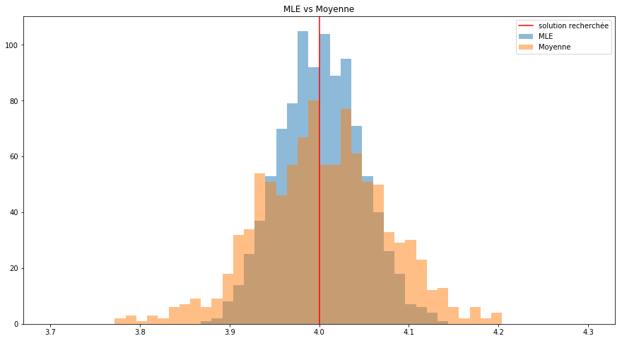

```python
plt.figure(figsize=(15,8))
x_b_l, x_b_moy=iter_x_b_mle_moy(x,sigma1,sigma2, n1,n2, N=1000)
plt.hist(x_b_l,range=(x-0.3,x+0.3),bins=50,label='MLE',alpha=0.5)
plt.hist(x_b_moy,range=(x-0.3,x+0.3),bins=50,label='Moyenne',alpha=0.5)
plt.axvline(x=4, label='solution recherchée', color='r')
plt.title('MLE vs Moyenne')
plt.legend()
plt.show()
```

**D'une part, les valeurs obtenues via les deux méthodes sont centrées autour de la solution recherchée $x$**

**D'autre part, on observe sans surprise que les valeurs obtenues par simple moyenne arithmétique sont plus écrasées autour de la solution recherchée $x=4$, et donc qu'à l'inverse les valeurs obtenues via l'agrégat $\overline{x}$ obtenu par maximum de vraisemblance sont plus proches et plus nombreuses autour de la solution recherchée $x$.**

### Question 3 :

*On généralise à présent l’expérience précédente à des cardinaux $n_1$ et $n_2$ variant de 1 à 20. Toujours pour 1000 réalisations, stockez dans un 2D numpy array l’écart-type des agrégats $\overline{x}$ en fonction de $n_1$ et $n_2$. Affichez ensuite ce tableau à l’aide de matplotlib.imshow (avec l’option interpolation=’none’).*

```python
x_b_iter=np.zeros((20,20))
for n1 in range(0,20):
    for n2 in range(0,20):
        x_b_l, _=iter_x_b_mle_moy(x,sigma1,sigma2,n1+1,n2+1, N=1000)
        x_b_iter[n1,n2]=np.std(x_b_l)
```

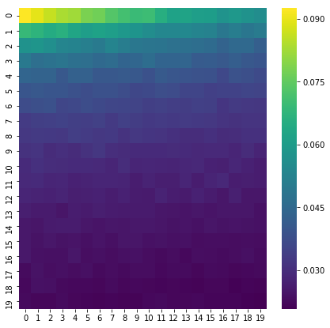

```python
plt.figure(figsize=(7,7))
sns.heatmap(x_b_iter, cmap='viridis')
```

**Pour le capteur 1, $\sigma_1=0.1$ et pour le capteur 2, $\sigma_2=0.3$.**

**Etant donné ces valeurs, il semble logique que le capteur 1 ait le plus d'influence sur la décroissance de l'écart-type. doù l'attrait du capteur 1 par rapport au capteur 2.**

### Question 4 :

Ici, l'agrégat MAP s'exprime comme le maximum *a posterior*. Dans ce cas :

$$\overline{x}=\frac{\frac{n_1\overline{x}_1}{\sigma_1^2}+\frac{n_2\overline{x}_2}{\sigma_0^2}+\frac{{x}_0}{\sigma_0^2}}{\frac{n_1}{\sigma_1^2}+\frac{n_2}{\sigma_2^2}+\frac{1}{\sigma_0^2}}$$

```python
# fonction x_map(x0,x1,x2,sigma0,sigma1,sigma2,n1,n2) pour calculer un agrégat MAP via l'expression ci-dessus.
def x_map(x0,x1,x2,sigma0,sigma1,sigma2,n1,n2):
    num=(n1*x1/sigma1**2)+(n2*x2/sigma2**2)+(x0/sigma0**2)
    dn=(n1/sigma1**2)+(n2/sigma2**2)+(1/sigma0**2)
    return num/dn
```

```python
N=1000
x=4
sigma1=0.1
sigma2=0.3
n1=3
n2=3
x_map_l=[]
for i in range(N):
    #Premier jeu de données pour calculer x0 et sigma0 :
    x1_b=np.mean(D(x,sigma1,n1)) #Moyenne empirique de D1
    x2_b=np.mean(D(x,sigma2,n2)) #Moyenne empirique de D2
    x0=x_b_mle(x1_b,x2_b,sigma1,sigma2,n1=3,n2=3) #Calcul de x0
    sigma0=x_b_iter[2,2] #sigma0 via l'array de la question précédente
    #On calcul selon le principe du MAP :
    x_map_l.append(x_map(x0,x1_b,x2_b,sigma0,sigma1,sigma2,n1,n2))
```

On compare avec l'approche *batch* où nous aurions obtenu les 12 données d'un coup :

```python
x_b_l, x_b_moy=iter_x_b_mle_moy(x,sigma1,sigma2, n1=6,n2=6, N=1000)
```

On affiche le résultat :

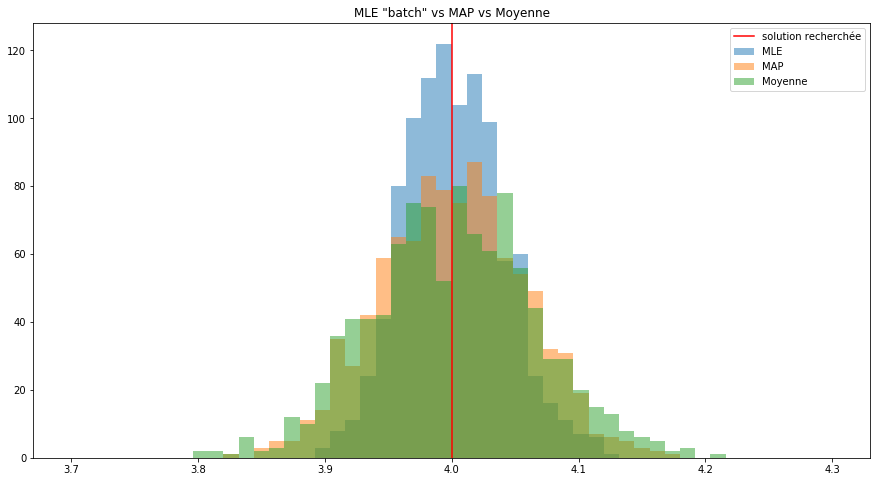

```python
plt.figure(figsize=(15,8))
plt.hist(x_b_l,range=(x-0.3,x+0.3),bins=50,label='MLE',alpha=0.5)
plt.hist(x_map_l,range=(x-0.3,x+0.3),bins=50,label='MAP',alpha=0.5)
plt.hist(x_b_moy,range=(x-0.3,x+0.3),bins=50,label='Moyenne',alpha=0.5)
plt.title('MLE "batch" vs MAP vs Moyenne')
plt.axvline(x=4, label='solution recherchée', color='r')
plt.legend()
plt.show()
```

**Toutes les approches permettent encore d'obtenir des valeurs autout de la solution recherché $x$**

**En ce qui concerne la validité des valeurs obtenues, nous observons que l'approche MAP se situe entre l'approche MLE et la moyenne.**

**Cela s'explique par la connaissance partielle dans l'approche MAP via le prior, qui permet d'avoir de meilleurs résultats que la moyenne, mais de moins bons que ceux obtenus avec l'approche MLE où toutes les données sont obtenues en une seule fois.**

## Exercice 2 : Fusion de capteurs de variances inconnues

### Question 1 :

*Reprenez le même problème qu’à la question 2 de l’exercice précédent mais en estimant conjointement $(\overline{x},\sigma_{1,mle},\sigma_{2,mle})$*

On a pour les écrats-type empiriques capteur par capteur :

$$\sigma_{1,mle}^2=\frac{1}{n_1}\sum^{n_1}_{k=1}(x_1^{(k)}-D)^2$$

et : $$\sigma_{2,mle}^2=\frac{1}{n_2}\sum^{n_2}_{k=1}(x_2^{(k)}-D)^2$$

Ces deux expressions font intervenir l'agrégat $D$ qui à présent se calcule en faisant intervenir lui aussi ces deux estimés :

$$\overline{x}=\frac{\sigma_{2,mle}^2\overline{x}^{(1)}n_1+\sigma_{1,mle}^2\overline{x}^{(2)}n_2}{\sigma_{2,mle}^2n_1+\sigma_{1,mle}^2n_2}$$

```python
#sigma_mle(X) pour estimer les écarts-type empiriques capteur par capteur
def sigma_mle(X):
    return np.sum((X-np.mean(X))**2)/n1

#x_b_mle_ex2(x1,x2,sigma1,sigma2,n1,n2) pour calculer un agrégat via l'expression donnée ci-dessus
def x_b_mle_ex2(x1,x2,sigma1,sigma2,n1,n2):
    num=sigma2**2 * n1*x1 +sigma1**2 *n2 *x2
    dn=sigma2**2 * n1 +sigma1**2 *n2
    return num/dn
```

```python
#Initialisation :
x=4 #solution recherchée
sigma1=0.1
sigma2=0.3
n1=4 #cardinal de D1
n2=10 #cardinal de D2

x_b_l_ex2=[]

for i in range(1000): #1000 réalisations
    X1=D(x,sigma1,n1) #Génération de D1
    X2=D(x,sigma2,n2) #génération de D2

    sigma1_mle=sigma_mle(X1) #estimation de sigma1
    sigma2_mle=sigma_mle(X2) #estimation de sigma2

    x_b_1=np.mean(X1) #moyenne empirique du capteur 1
    x_b_2=np.mean(X2) #moyenne empirique du capteur

    #nouvelle estimation ajoutée à la liste des estimations :
    x_b_l_ex2.append(x_b_mle_ex2(x_b_1,x_b_2,sigma1_mle,sigma2_mle,n1,n2))
```

On affiche le résultat :

[figure not shown]

```python
x_b_l, x_b_moy=iter_x_b_mle_moy(x,sigma1,sigma2, n1,n2, N=1000)
#Affichage des histogrammes :
plt.figure(figsize=(15,8))
plt.hist(x_b_l,range=(x-0.3,x+0.3),bins=50,label='MLE',alpha=0.5)
plt.hist(x_b_l_ex2,range=(x-0.3,x+0.3),bins=50,label='MLE exercie 2',alpha=0.5)
plt.hist(x_b_moy,range=(x-0.3,x+0.3),bins=50,label='Moyenne',alpha=0.5)
plt.axvline(x=4, label='solution recherchée', color='r')
plt.title('MLE variance connue vs MLE variance inconnue vs Moyenne')
#Légende :
plt.legend()
plt.show()
```

**Ici, l'estimation est moins bonne pour la méthode MLE de cet exercice où les variances doivent être estimées qu'avec la méthode MLE de l'exercice 1 où les variances sont connues.**

**En clair, à l'instar de l'exercice précédent, plus les données du problème sont connues meilleure est l'estimation.**